```python
from __future__ import annotations

from pathlib import Path
from typing import Any

import matplotlib.pyplot as plt

from example_models import get_linear_chain_2v
from mxlpy.types import unwrap


def print_annotated(description: str, value: Any) -> None:
    print(
        description,
        value,
        sep="\n",
        end="\n\n",
    )
```

from __future__ import annotations from pathlib import Path from typing import Any import matplotlib.pyplot as plt from example_models import get_linear_chain_2v from mxlpy.types import unwrap def print_annotated(description: str, value: Any) -> None: print( description, value, sep="\n", end="\n\n", )

# Model building basics

In the following you will learn how to build and simulate your first model using `mxlpy`.

This will allow you to create time courses and do steady-state analysis as shown below.

[figure not shown]

## Defining your first model

Let's say you want to model the following chemical network of a linear chain of reactions

$$ \Large \varnothing \xrightarrow{v_0} S \xrightarrow{v_1} P \xrightarrow{v_2} \varnothing $$

We can translate this into a system of ordinary differential equations (ODEs)

$$\begin{align*} \frac{dS}{dt} &= v_0 - v_1 \\ \frac{dP}{dt} &= v_1 - v_2 \\ \end{align*} $$

Note that the rates $v$ effect the variables by certain factors, known as **stoichiometries**.  
We can explicity write out these factors like this:

$$\begin{align*} \frac{dS}{dt} &= 1 \cdot v_0 -1 \cdot v_1 \\ \frac{dP}{dt} &= 1\cdot v_1 -1 \cdot v_2 \\ \end{align*} $$

In the example the stoichiometries are all $1$ or $-1$, however, they can have any real value.  
We can write out the stoichiometries using a **stoichiometric matrix**:

| Variable | $v_0$ | $v_1$ | $v_2$ |
| --- | --- | --- | --- |
| S | 1 | -1 | 0 |
| P | 0 | 1 | -1 |

Which we can read as (ignoring the 0 entries):

- `S` is produced by $v_0$ and consumed by $v_1$
- `P` is produced by $v_1$ and consumed by $v_2$

Lastly we choose rate equations for each rate to get the flux vector $v$

$$\begin{align*} v_0 &= k_{in} \\ v_1 &= k_1 * S \\ v_2 &= k_{out} * P \\ \end{align*}$$

## Implementing your first model

Now let's implement this first model in *mxlpy*.  
We start by creating the rate functions $\textbf{v}$.  
Note that these should be **general** and **re-usable** whenever possible, to make your model clear to people reading it.  
Try to give these functions names that are meaningful to your audience, e.g. a rate function `k * s` could be named **proportional** or **mass-action**.

```python
def constant(k: float) -> float:
    return k


def proportional(k: float, s: float) -> float:
    return k * s
```

def constant(k: float) -> float: return k def proportional(k: float, s: float) -> float: return k * s

Next, we create our model.

For this, we first import the `Model` class from the `mxlpy` package.

```python
from mxlpy import Model

model = Model()
```

from mxlpy import Model model = Model()

We first add parameters to the model using `.add_parameters({name: value})`.

> Note that the function returns our `Model` object again.  
> This will be useful later, as we can *chain* multiple calls together.

```python
model = model.add_parameters({"k_in": 1, "k_1": 1, "k_out": 1})
```

model = model.add_parameters({"k_in": 1, "k_1": 1, "k_out": 1})

Next we add the dynamic variables `S` and `P` with their respective initial condition.

```python
model = model.add_variables({"S": 0, "P": 0})
```

model = model.add_variables({"S": 0, "P": 0})

Finally, we add the three reactions by using

```
.add_reaction(
    name,              # the internal name for the reaction
    fn=...,            # a python function to be evaluated
    args=[name, ...]   # the arguments passed to the python function
    stoichiometry={    # a mapping encoding how much the variable `name`
        name: value    # is changed by the reaction
    },
)
```

> **Attention**  
> There are a couple of points to note here.  
> First, the function passed to `fn` here (and elsewhere) needs to be pickle-able  
> Thus, **lambda** functions are not supported!

> Second, the arguments defined with `args` are passed to `fn` **by position**, not by name.  
> Thus, the *order* of arguments in `args` needs to match the order of arguments in `fn`

```python
model.add_reaction(
    "v0",
    fn=constant,
    args=["k_in"],
    stoichiometry={"S": 1},  # produces one S
)
model.add_reaction(
    "v1",
    fn=proportional,
    args=["k_1", "S"],  # note that the order needs to match `proportional`
    stoichiometry={"S": -1, "P": 1},  # consumes one S and produces one P
)
model.add_reaction(
    "v2",
    fn=proportional,
    args=["k_out", "P"],  # note that the order needs to match `proportional`
    stoichiometry={"P": -1},  # exports one P
)

print(model.get_reaction_names())
```

model.add_reaction( "v0", fn=constant, args=["k_in"], stoichiometry={"S": 1}, # produces one S ) model.add_reaction( "v1", fn=proportional, args=["k_1", "S"], # note that the order needs to match `proportional` stoichiometry={"S": -1, "P": 1}, # consumes one S and produces one P ) model.add_reaction( "v2", fn=proportional, args=["k_out", "P"], # note that the order needs to match `proportional` stoichiometry={"P": -1}, # exports one P ) print(model.get_reaction_names())

```
['v0', 'v1', 'v2']
```

Note, that we in general recommend to use a single function that returns the model instead of defining it globally.  
This allows us to quickly re-create the model whenever we need a fresh version of it.  
Below, we define the same model again, but inside a single function.

> Note that we made use of **operator chaining** to avoid having to write `model` for every call.

So we can write `Model.method1().method2()...` instead of having to write

```
model.method1()
model.method2()
```

etc

```python
def create_linear_chain_model() -> Model:
    return (
        Model()
        .add_parameters({"k_in": 1, "k_1": 1, "k_out": 1})
        .add_variables({"S": 0, "P": 0})
        .add_reaction(
            "v0",
            fn=constant,
            args=["k_in"],
            stoichiometry={"S": 1},  # produces one S
        )
        .add_reaction(
            "v1",
            fn=proportional,
            args=["k_1", "S"],  # note that the order needs to match `proportional`
            stoichiometry={"S": -1, "P": 1},  # consumes one S and produces one P
        )
        .add_reaction(
            "v2",
            fn=proportional,
            args=["k_out", "P"],  # note that the order needs to match `proportional`
            stoichiometry={"P": -1},  # exports one P
        )
    )
```

def create_linear_chain_model() -> Model: return ( Model() .add_parameters({"k_in": 1, "k_1": 1, "k_out": 1}) .add_variables({"S": 0, "P": 0}) .add_reaction( "v0", fn=constant, args=["k_in"], stoichiometry={"S": 1}, # produces one S ) .add_reaction( "v1", fn=proportional, args=["k_1", "S"], # note that the order needs to match `proportional` stoichiometry={"S": -1, "P": 1}, # consumes one S and produces one P ) .add_reaction( "v2", fn=proportional, args=["k_out", "P"], # note that the order needs to match `proportional` stoichiometry={"P": -1}, # exports one P ) )

We can then simulate the model by passing it to a `Simulator` and simulate a time series using `.simulate(t_end)`.  
Finally, we can obtain the concentrations and fluxes using `get_result`.

While you can directly plot the `pd.DataFrame`s, mxlpy supplies a variety of plots in the `plot` namespace that are worth checking out.

```python
from mxlpy import Simulator, plot

res = (
    Simulator(create_linear_chain_model())  # initialise the simulator
    .simulate(5)  # simulate until t_end = 5 a.u.
    .get_result()  # return pd.DataFrames for concentrations and fluxes
)

if res is not None:
    variables, fluxes = res

    fig, (ax1, ax2) = plot.two_axes(figsize=(6, 2.5))
    _ = plot.lines(variables, ax=ax1)
    _ = plot.lines(fluxes, ax=ax2)

    # Never forget to labelr you axes :)
    ax1.set(xlabel="time / a.u.", ylabel="concentration / a.u.")
    ax2.set(xlabel="time / a.u.", ylabel="flux / a.u.")
    plt.show()
```

from mxlpy import Simulator, plot res = ( Simulator(create_linear_chain_model()) # initialise the simulator .simulate(5) # simulate until t_end = 5 a.u. .get_result() # return pd.DataFrames for concentrations and fluxes ) if res is not None: variables, fluxes = res fig, (ax1, ax2) = plot.two_axes(figsize=(6, 2.5)) _ = plot.lines(variables, ax=ax1) _ = plot.lines(fluxes, ax=ax2) # Never forget to labelr you axes :) ax1.set(xlabel="time / a.u.", ylabel="concentration / a.u.") ax2.set(xlabel="time / a.u.", ylabel="flux / a.u.") plt.show()

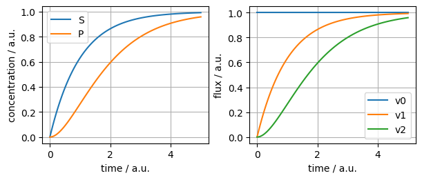

Note, that we checked whether the results were `None` in case the simulation failed.  
Explicitly checking using an `if` clause is the prefered error handling mechanism.

If you are **sure** the simulation won't fail, and still want your code to be type-safe, you can use `unwrap`.

```
variables, fluxes = unwrap(Simulator(model).simulate(10).get_result())
```

Note that these functions will throw an error if the values are `None`, which potentially might crash your programs.

## Derived quantities

Frequently it makes sense to derive one quantity in a model from other quantities.  
This can be done for

- parameters derived from other parameters
- variables derived from parameters or other variables
- stoichiometries derived from parameters or variables (more on this later)

*mxlpy* offers a unified interface for derived parameters and variables usign `Model.add_derived()`.

```python
def moiety_1(x1: float, total: float) -> float:
    return total - x1


def model_derived() -> Model:
    return (
        Model()
        .add_variables({"ATP": 1.0})
        .add_parameters({"ATP_total": 1.0, "k_base": 1.0, "e0_atpase": 1.0})
        .add_derived("k_atp", proportional, args=["k_base", "e0_atpase"])
        .add_derived("ADP", moiety_1, args=["ATP", "ATP_total"])
        .add_reaction(
            "ATPase", proportional, args=["k_atp", "ATP"], stoichiometry={"ATP": -1}
        )
    )


variables, fluxes = unwrap(Simulator(model_derived()).simulate(10).get_result())
fig, ax = plot.lines(variables)
ax.set(xlabel="time / a.u.", ylabel="concentration / a.u.")
plt.show()
```

def moiety_1(x1: float, total: float) -> float: return total - x1 def model_derived() -> Model: return ( Model() .add_variables({"ATP": 1.0}) .add_parameters({"ATP_total": 1.0, "k_base": 1.0, "e0_atpase": 1.0}) .add_derived("k_atp", proportional, args=["k_base", "e0_atpase"]) .add_derived("ADP", moiety_1, args=["ATP", "ATP_total"]) .add_reaction( "ATPase", proportional, args=["k_atp", "ATP"], stoichiometry={"ATP": -1} ) ) variables, fluxes = unwrap(Simulator(model_derived()).simulate(10).get_result()) fig, ax = plot.lines(variables) ax.set(xlabel="time / a.u.", ylabel="concentration / a.u.") plt.show()

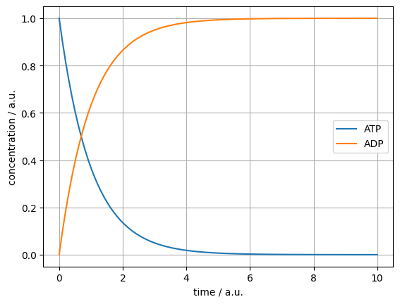

## Introspection

If the simulation didn't show the expected results, it is usually a good idea to try to pinpoint the error.  
`mxlpy` offers a variety of methods to access intermediate results.

The first is to check whether all **derived quantities** were calculate correctly.  
For this, you can use the `get_args` method, which is named consistently with the `args` argument in all methods like `add_reaction`.

```python
m = create_linear_chain_model()

print_annotated(
    "Using initial conditions as default:",
    m.get_args(),
)

print_annotated(
    "Using custom concentrations:",
    m.get_args({"S": 1.0, "P": 0.5}),
)
```

m = create_linear_chain_model() print_annotated( "Using initial conditions as default:", m.get_args(), ) print_annotated( "Using custom concentrations:", m.get_args({"S": 1.0, "P": 0.5}), )

```
Using initial conditions as default:
S    0.0
P    0.0
dtype: float64

Using custom concentrations:
S    1.0
P    0.5
dtype: float64
```

If the `args` look fine, the next step is usually to check whether the rate equations are looking as expected

```python
m = create_linear_chain_model()
print_annotated(
    "Using initial conditions as default:",
    m.get_fluxes(),
)
print_annotated(
    "Using custom concentrations:",
    m.get_fluxes({"S": 1.0, "P": 0.5}),
)
```

m = create_linear_chain_model() print_annotated( "Using initial conditions as default:", m.get_fluxes(), ) print_annotated( "Using custom concentrations:", m.get_fluxes({"S": 1.0, "P": 0.5}), )

```
Using initial conditions as default:
v0    1.0
v1    0.0
v2    0.0
dtype: float64

Using custom concentrations:
v0    1.0
v1    1.0
v2    0.5
dtype: float64
```

and whether the stoichiometries are assigned correctly

```python
m = create_linear_chain_model()
m.get_stoichiometries()
```

m = create_linear_chain_model() m.get_stoichiometries()

|  | v0 | v1 | v2 |
| --- | --- | --- | --- |
| S | 1.0 | -1.0 | 0.0 |
| P | 0.0 | 1.0 | -1.0 |

Lastly, you can check the generated right hand side

```python
m = create_linear_chain_model()

print_annotated(
    "Using initial conditions as default:",
    m.get_right_hand_side(),
)

print_annotated(
    "Using custom concentrations:",
    m.get_right_hand_side({"S": 1.0, "P": 0.5}),
)
```

m = create_linear_chain_model() print_annotated( "Using initial conditions as default:", m.get_right_hand_side(), ) print_annotated( "Using custom concentrations:", m.get_right_hand_side({"S": 1.0, "P": 0.5}), )

```
Using initial conditions as default:
S    1.0
P    0.0
dtype: float64

Using custom concentrations:
S    0.0
P    0.5
dtype: float64
```

If any of the quantities above were unexpected, you can check the model interactively by accessing the various collections.

> Note: the returned quantities are **copies** of the internal data, modifying these won't have any effect on the model

```python
print_annotated("Parameters", m.parameters)
print_annotated("Variables", m.variables)
print_annotated("Reactions", m.reactions)
```

print_annotated("Parameters", m.parameters) print_annotated("Variables", m.variables) print_annotated("Reactions", m.reactions)

[output not shown]

In case you model contains derived quantitites you can access the derived quantities using `.derived`.  
Note that this returns a **copy** of the derived quantities, so editing it won't have any effect on the model.

```python
model_derived().derived
```

model_derived().derived

```
{'k_atp': Derived(fn=<function proportional at 0x7ff664068040>, args=['k_base', 'e0_atpase']),
 'ADP': Derived(fn=<function moiety_1 at 0x7ff66422aca0>, args=['ATP', 'ATP_total'])}
```

## CRUD

The model has a complete **c**reate, **r**ead, **u**pdate, **d**elete API for all it's elements.  
The methods and attributes are named consistenly, with `add` instead of `create` and `get` instead of `read`.  
Note that the elements itself are accessible as `properties`, e.g. `.parameters` which will return **copies** of the data.  
Only use the supplied methods to change the internal state of the model.

Here are some example methods and attributes for parameters

| Functionality | Parameters |
| --- | --- |
| Create | `.add_parameter()`, `.add_parameters()` |
| Read | `.parameters`, `.get_parameter_names()` |
| Update | `.update_parameter()`, `.update_parameters()`, `.scale_parameter()`, `scale.parameters()` |
| Delete | `.remove_parameter()`, `.remove_parameters()` |

and variables

| Functionality | Variables |
| --- | --- |
| Create | `.add_variable()`, `.add_variables()` |
| Read | `.variables`, `.get_variable_names()`, `get_initial_conditions()` |
| Update | `.update_variable()`, `.update_variables()` |
| Delete | `.remove_parameter()`, `.remove_parameters()` |

```python
m = create_linear_chain_model()

# Calculate fluxes
print_annotated(
    "Before update",
    m.get_fluxes({"S": 1.0, "P": 0.5}),
)

# Update parameters
m.update_parameters({"k_in": 2.0})

# Calculate fluxes again
print_annotated(
    "After update",
    m.get_fluxes({"S": 1.0, "P": 0.5}),
)
```

m = create_linear_chain_model() # Calculate fluxes print_annotated( "Before update", m.get_fluxes({"S": 1.0, "P": 0.5}), ) # Update parameters m.update_parameters({"k_in": 2.0}) # Calculate fluxes again print_annotated( "After update", m.get_fluxes({"S": 1.0, "P": 0.5}), )

```
Before update
v0    1.0
v1    1.0
v2    0.5
dtype: float64

After update
v0    2.0
v1    1.0
v2    0.5
dtype: float64
```

## Derived stoichiometries

To define derived stoichiometries can make them dependent on parameters in the model or use the `Derived` class as a value in the stoichiometries.

So instead of defining them like this

`stoichiometry={"x": 1.0}`

you can use

`stoichiometry={"x": "stoich"}`

or for more advanced uses you use the `Derived` class as the value

`stoichiometry={"x": Derived(fn=constant, args=["stoich"])}`

```python
variables, fluxes = unwrap(
    Simulator(
        Model()
        .add_parameters({"stoich": -1.0, "k": 1.0})
        .add_variables({"x": 1.0})
        .add_reaction(
            "name",
            proportional,
            args=["x", "k"],
            # Define derived stoichiometry here
            stoichiometry={"x": "stoich"},
        )
    )
    .simulate(1)
    # Update parameter the derived stoichiometry depends on
    .update_parameter("stoich", -4.0)
    # Continue simulation
    .simulate(5)
    .get_result()
)

_, ax = plot.lines(variables)
ax.set(xlabel="time / a.u.", ylabel="concentration / a.u.")
plt.show()
```

variables, fluxes = unwrap( Simulator( Model() .add_parameters({"stoich": -1.0, "k": 1.0}) .add_variables({"x": 1.0}) .add_reaction( "name", proportional, args=["x", "k"], # Define derived stoichiometry here stoichiometry={"x": "stoich"}, ) ) .simulate(1) # Update parameter the derived stoichiometry depends on .update_parameter("stoich", -4.0) # Continue simulation .simulate(5) .get_result() ) _, ax = plot.lines(variables) ax.set(xlabel="time / a.u.", ylabel="concentration / a.u.") plt.show()

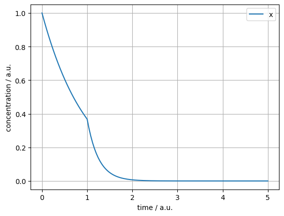

## Simulations: time courses

Time courses are simulations over time

[figure not shown]

You can obtain the time course of integration using the `simulate` method.  
There are two ways how you can define the time points this function returns.

1. supply the end time `t_end`
2. supply both end time and number of steps with `t_end` and `steps`

If you want to set the exact time points to be returned use `simulate_time_course`

```
simulate(t_end=10)
simulate(t_end=10, steps=10)
simulate_time_course(np.linspace(0, 10, 11))
```

```python
variables, fluxes = unwrap(
    Simulator(get_linear_chain_2v())
    .simulate(t_end=10)  # simulate until t_end = 10 a.u.
    .get_result()
)

fig, ax = plot.lines(variables)
ax.set(xlabel="time / a.u.", ylabel="concentration / a.u.")
plt.show()
```

variables, fluxes = unwrap( Simulator(get_linear_chain_2v()) .simulate(t_end=10) # simulate until t_end = 10 a.u. .get_result() ) fig, ax = plot.lines(variables) ax.set(xlabel="time / a.u.", ylabel="concentration / a.u.") plt.show()

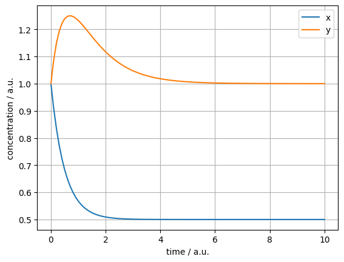

By default, the `Simulator` is initialised with the initial concentrations set in the `Model`.  
Optionally, you can overwrite the initial conditions using the `y0` argument.

```
Simulator(model, y0={name: value, ...})
```

```python
variables, fluxes = unwrap(
    Simulator(create_linear_chain_model(), y0={"S": 2.0, "P": 0.0})
    .simulate(10)
    .get_result()
)

fig, (ax1, ax2) = plot.two_axes(figsize=(6, 3))
_ = plot.lines(variables, ax=ax1)
_ = plot.lines(fluxes, ax=ax2)

ax1.set(xlabel="time / a.u.", ylabel="concentration / a.u.")
ax2.set(xlabel="time / a.u.", ylabel="flux / a.u.")
plt.show()
```

variables, fluxes = unwrap( Simulator(create_linear_chain_model(), y0={"S": 2.0, "P": 0.0}) .simulate(10) .get_result() ) fig, (ax1, ax2) = plot.two_axes(figsize=(6, 3)) _ = plot.lines(variables, ax=ax1) _ = plot.lines(fluxes, ax=ax2) ax1.set(xlabel="time / a.u.", ylabel="concentration / a.u.") ax2.set(xlabel="time / a.u.", ylabel="flux / a.u.") plt.show()

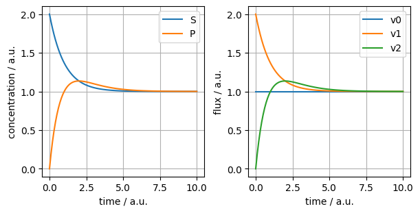

## Simulations: protocol time course

Protocols are used to make parameter changes discrete in time, such as turning a light on and off.  
This is useful reproducing experimental time courses where a parameter was changed at fixed time points.

[figure not shown]

The protocol is defined as a `pandas.DataFrame` using `pd.Timedelta` values as in index, and the parameter values at the respective time interval as values.

| pd.Timedelta | p1 | p2 |
| --- | --- | --- |
| 0 days 00:00:01 | 1 | 0 |
| 0 days 00:00:03 | 2 | 1 |
| 0 days 00:00:06 | 1 | 2 |

You can use as many parameters as you want.

> **Note**  
> *mxlpy* assigns one second of the `Timedelta` to one **time unit** of the integration.  
> mxlpy does **not** take into account whether your integration might use a different time unit.

For convenience, we supply the `make_protocol` function, which takes in a pair of the **duration** of the time-step on the respective **parameter values**.

```python
from mxlpy import make_protocol

protocol = make_protocol(
    [
        (1, {"k1": 1}),  # for one second value of 1
        (2, {"k1": 2}),  # for two seconds value of 2
        (3, {"k1": 1}),  # for three seconds value of 1
    ]
)
protocol
```

from mxlpy import make_protocol protocol = make_protocol( [ (1, {"k1": 1}), # for one second value of 1 (2, {"k1": 2}), # for two seconds value of 2 (3, {"k1": 1}), # for three seconds value of 1 ] ) protocol

| Timedelta | k1 |
| --- | --- |
| 0 days 00:00:01 | 1 |
| 0 days 00:00:03 | 2 |
| 0 days 00:00:06 | 1 |

Now instead of running `simulate` or `simulate_time_course` we use `simulate_over_protocol`

```python
variables, fluxes = unwrap(
    Simulator(get_linear_chain_2v()).simulate_over_protocol(protocol).get_result()
)

fig, ax = plt.subplots()
plot.lines(variables, ax=ax)
plot.shade_protocol(protocol["k1"], ax=ax, alpha=0.1)
ax.set(xlabel="time / a.u.", ylabel="concentration / a.u.")
plt.show()
```

variables, fluxes = unwrap( Simulator(get_linear_chain_2v()).simulate_over_protocol(protocol).get_result() ) fig, ax = plt.subplots() plot.lines(variables, ax=ax) plot.shade_protocol(protocol["k1"], ax=ax, alpha=0.1) ax.set(xlabel="time / a.u.", ylabel="concentration / a.u.") plt.show()

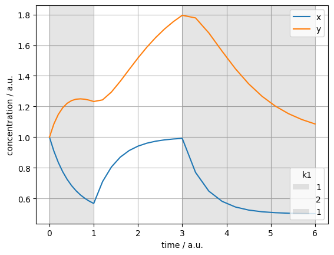

## Simulations: steady-state

A steady-state describes a state at which the concentrations of the system don't change anymore (also called fixed points).

[figure not shown]

You can simulate until the model reaches a steady-state using the `simulate_to_steady_state` method.

```python
variables, fluxes = unwrap(
    Simulator(get_linear_chain_2v())  # optionally supply initial conditions
    .simulate_to_steady_state()
    .get_result()
)

fig, ax = plot.bars(variables)
ax.set(xlabel="Variable / a.u.", ylabel="Concentration / a.u.")
plt.show()
```

variables, fluxes = unwrap( Simulator(get_linear_chain_2v()) # optionally supply initial conditions .simulate_to_steady_state() .get_result() ) fig, ax = plot.bars(variables) ax.set(xlabel="Variable / a.u.", ylabel="Concentration / a.u.") plt.show()

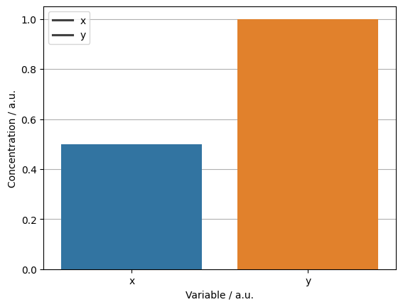

## SBML

The systems biology markup language (SBML) is a widely used file format for sharing models between different software packages and programming languages.

`mxlpy` supports reading and writing **sbml** models using the `sbml.read` and `sbml.write` functions.

```python
from mxlpy import sbml

model = sbml.read(Path("assets") / "00001-sbml-l3v2.xml")
variables, fluxes = unwrap(Simulator(model).simulate(10).get_result())
_ = plot.lines(variables)
```

from mxlpy import sbml model = sbml.read(Path("assets") / "00001-sbml-l3v2.xml") variables, fluxes = unwrap(Simulator(model).simulate(10).get_result()) _ = plot.lines(variables)

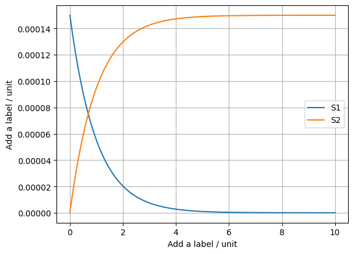

When exporting a model, you can supply additional meta-information like units and compartmentalisation.  
See the [official sbml documentation](https://sbml.org/documents/) for more information of legal values.

```python
sbml.write(
    model,
    file=Path(".cache") / "model.xml",
    extent_units="mole",
    substance_units="mole",
    time_units="second",
)
```

sbml.write( model, file=Path(".cache") / "model.xml", extent_units="mole", substance_units="mole", time_units="second", )

```
PosixPath('.cache/model.xml')
```

## First finish line

With that you now know most of what you will need from a day-to-day basis about model building and simulation in mxlpy.  
Congratulations!

## Advanced topics

### Time-dependent reactions

You can use the special name `time` to refer to the actual integration time in the rare case a reaction or module depends on it explicitly.  
This is why the methods `get_args`, `get_fluxes` etc. also take an additional `time` argument.

```python
def time_dependency() -> Model:
    return (
        Model()
        .add_variable("x", 1.0)
        .add_reaction(
            "v1",
            proportional,
            args=["time", "x"],
            stoichiometry={"x": -1},
        )
    )


model = time_dependency()

# Watch our for explicit time dependency here!
print_annotated(
    "Fluxes at time = 1.0",
    model.get_fluxes(time=1.0),
)
print_annotated(
    "Fluxes at time = 2.0",
    model.get_fluxes(time=2.0),
)

# During simulations the time is automatically taken care of
_ = unwrap(Simulator(model).simulate(t_end=10).get_result()).variables.plot(
    xlabel="time / a.u.",
    ylabel="amount / a.u.",
    title="Time-dependent reaction",
)
```

def time_dependency() -> Model: return ( Model() .add_variable("x", 1.0) .add_reaction( "v1", proportional, args=["time", "x"], stoichiometry={"x": -1}, ) ) model = time_dependency() # Watch our for explicit time dependency here! print_annotated( "Fluxes at time = 1.0", model.get_fluxes(time=1.0), ) print_annotated( "Fluxes at time = 2.0", model.get_fluxes(time=2.0), ) # During simulations the time is automatically taken care of _ = unwrap(Simulator(model).simulate(t_end=10).get_result()).variables.plot( xlabel="time / a.u.", ylabel="amount / a.u.", title="Time-dependent reaction", )

```
Fluxes at time = 1.0
v1    1.0
dtype: float64

Fluxes at time = 2.0
v1    2.0
dtype: float64
```

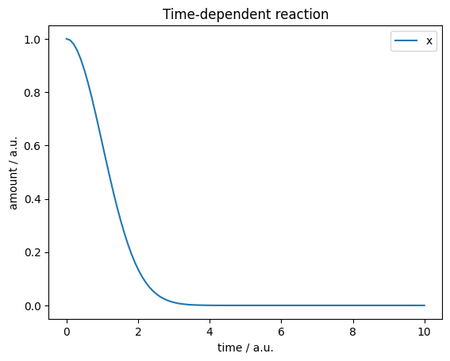

### Derived parameters and variables

Internally mxlpy differentiates between derived *parameters* and derived *variables*.  
This differentiation is just-in-time before any calculation and thus might change if you change the nature of a parameter / variable.

If you are interested in which category mxlpy has placed the derived quantities, you can access `.derived_parameters` and `.derived_variables` as well.

```python
def model_derived() -> Model:
    return (
        Model()
        .add_variables({"ATP": 1.0})
        .add_parameters({"ATP_total": 1.0, "k_base": 1.0, "e0_atpase": 1.0})
        .add_derived("k_atp", proportional, args=["k_base", "e0_atpase"])
        .add_derived("ADP", moiety_1, args=["ATP", "ATP_total"])
        .add_reaction(
            "ATPase", proportional, args=["k_atp", "ATP"], stoichiometry={"ATP": -1}
        )
    )


m = Model().add_parameters({"x1": 1.0}).add_derived("x1d", constant, args=["x1"])
print("Derived Parameters:", m.derived_parameters)
print("Derived Variables:", m.derived_variables)

print("\nMaking x1 dynamic")
m.make_parameter_dynamic("x1")
print("Derived Parameters:", m.derived_parameters)
print("Derived Variables:", m.derived_variables)
```

def model_derived() -> Model: return ( Model() .add_variables({"ATP": 1.0}) .add_parameters({"ATP_total": 1.0, "k_base": 1.0, "e0_atpase": 1.0}) .add_derived("k_atp", proportional, args=["k_base", "e0_atpase"]) .add_derived("ADP", moiety_1, args=["ATP", "ATP_total"]) .add_reaction( "ATPase", proportional, args=["k_atp", "ATP"], stoichiometry={"ATP": -1} ) ) m = Model().add_parameters({"x1": 1.0}).add_derived("x1d", constant, args=["x1"]) print("Derived Parameters:", m.derived_parameters) print("Derived Variables:", m.derived_variables) print("\nMaking x1 dynamic") m.make_parameter_dynamic("x1") print("Derived Parameters:", m.derived_parameters) print("Derived Variables:", m.derived_variables)

```
Derived Parameters: {'x1d': Derived(fn=<function constant at 0x7ff664063f60>, args=['x1'])}
Derived Variables: {}

Making x1 dynamic
Derived Parameters: {}
Derived Variables: {'x1d': Derived(fn=<function constant at 0x7ff664063f60>, args=['x1'])}
```